# PROseq data analysis

Jenny Jakobsson

11/9/2020

# PROseq data analysis

Analysis of the differential expression between the samples. The evaluation is done by the output from PROseq which is read counts per gene

## Loading data

We load the count table of the expressed genes counted per gene. This is the reads from PROseq

```r
# Loading the count tsv file that contains info and the read count for each gene
featureCountFile = paste(params$workingDir, params$dataDir, params$CountData, sep = "/")
FCdata = read.table(
  file = featureCountFile,
  header = TRUE,
  sep = "\t",
  quote = "",
  stringsAsFactors = FALSE
)

# Saving the info about the genes;geneID, chr, start, end, strand and gene length
positions = FCdata[, 1:6]
# The columns chr, start, end and strand have multiple values for chr and strand it is enough to just take the first value since all values are the same
chr = positions %>% dplyr::select(Geneid, Chr)
chr = chr  %>% separate(
  col = Chr,
  into = c("chr"),
  sep = ";",
  remove = TRUE
)
strand = positions %>% dplyr::select(Geneid, Strand)
strand = strand %>% separate(
  col = Strand,
  into = c("strand"),
  sep = ";",
  remove = TRUE
)
positions = inner_join(positions, chr, by = "Geneid")
positions = inner_join(positions, strand, by = "Geneid")

# Creating matrix for the countdata, geneID and count for each sample
countData = FCdata[, -1:-6]
FCgeneID = FCdata[, 1]
rownames(countData) = FCgeneID
```

### Extracting the positions of the genes

The columns start and end from the count data have multiple values. To include as big of a region as possible the earliest start and the latest end is extracted. min(start), max(end)

```r
# Ran iterative loops to get the max number of values for start and stop is 1723 and therefore the number of columns = 1723
# Create the starting variables for the loop
start_matrix = matrix(NA, nrow = 13947, ncol = 1723)
vector = c()
start = positions %>% dplyr::select(Start, Geneid)
num_rows = dim(start)[1]
start$start_min = NA

# Splitting the values for each row(gene)
for (start_row in 1:num_rows) {
  vector = str_split(start[[1]][start_row], ";")
  num_cols = length(vector[[1]])
  for (start_col in 1:num_cols) {
    # Saving each value in a separate column
    start_matrix[start_row, start_col] = vector[[1]][start_col]
  }
  # Find the minimum value of all the start values for each gene
  min_col = which.min(start_matrix[start_row,])
  # Extract the start position and save it in a new column called start_min
  start$start_min[start$Geneid == start[[2]][start_row]] = start_matrix[start_row, min_col]
}

# Create the starting variables for the loop
end_matrix = matrix(NA, nrow = 13948, ncol = 1723)
vector = c()
end = positions %>% dplyr::select(End, Geneid)
rows = dim(end)[1]
end$end_max = NA

# Splitting the values for each row(gene)
for (end_row in 1:rows) {
  vector = str_split(end[[1]][end_row], ";")
  cols = length(vector[[1]])
  for (end_col in 1:cols) {
    # Saving each value in a separate column
    end_matrix[end_row, end_col] = vector[[1]][end_col]
  }
  # Find the maximum value of all the end values for each gene
  max_col = which.max(end_matrix[end_row,])
  # Extract the end position and save it in a new column called end_max
  end$end_max[end$Geneid == end[[2]][end_row]] = end_matrix[end_row, max_col]
}

# Need to connect the correct start and end with the correct gene and therefore the data is joined on geneID
positions_fixed = inner_join(positions, start, by = "Geneid")
positions_fixed = inner_join(positions_fixed, end, by = "Geneid")
positions_fixed = positions_fixed %>% dplyr::select(Geneid, chr, start_min, end_max, strand, Length)
# Rename the columns to the universal names
geneInfo = positions_fixed %>% dplyr::rename(
  geneID = Geneid,
  Chr = chr,
  Start = start_min,
  End = end_max,
  Strand = strand
)
```

## Create sample information

Extracting the information from the sample name so it is more easily accessible in a data frame. The sample information is sample name, mutant, time, replicate and bam file name.

```r
# Extract the information about the samples from the sampleName. The info is saved in the same columns so it needs to be seperated.
# Save sampleName, mutant, time, replicate and name of the bam file.
sampleInfo = data.frame(bamFile =  colnames(countData))
sampleInfo = sampleInfo %>% separate(
  col = bamFile,
  sep = "\\.",
  into =  c("Dir", "mutant", "sampleInfo"),
  remove = FALSE
)
sampleInfo = sampleInfo %>% separate(
  col = sampleInfo,
  sep = "_",
  into =  c("irrelevant", "time", "replicate")
)
sampleInfo = sampleInfo %>% separate(col = mutant,
                                     sep = "_",
                                     into =  c("mutant"))
sampleInfo = sampleInfo %>% dplyr::select(bamFile, mutant, time, replicate)
sampleInfo = sampleInfo %>% unite("sampleName", mutant:time:replicate, remove = FALSE)
sampleInfo = sampleInfo %>% dplyr::select(bamFile, sampleName, mutant, time, replicate)

# Save the sample info. It will include name, mutant, time, replicate and bamfile name.
rownames(sampleInfo) = sampleInfo$bamFile
sampleInfo = sampleInfo[colnames(countData), ]
colnames(countData) = sampleInfo$sampleName
rownames(sampleInfo) = sampleInfo$sampleName
sampleInfo = sampleInfo %>% dplyr::select(sampleName, mutant, time, replicate, bamFile)
```

## Expression filtering

```r
# Derive the logarithm of the counts
geneExpression = log(rowSums(countData))
geneInfo$logExpression = log(rowSums(countData))

# Filter out all genes with no expression(counts = 0 --> log(count)=1)
geneInfo.QC = geneInfo %>% filter(logExpression > 1)

# Save only the count data with genes with expression
countData.QC =  countData[geneInfo.QC$geneID, ]
```

## Add information about genes involved in the differentiation of the tissues.

A file with gene information has been downloaded from the FlyBase database. The gene IDs are compared to the geneIDs in the expression data.

```r
# Load the geneIDs from the Flybase genes
knownGenes = read.table(
  file = paste(
    params$workingDir,
    params$informationDir,
    "FlyBase_IDs.txt",
    sep = "/"
  ),
  sep = "\t",
  header = F,
  quote = "",
  stringsAsFactors = F
)
# Add name for the columns since the header was removed in the previous command
colnames(knownGenes) = c("Submitted ID", "Current ID", "Converted ID", "Related record")

# Set default value for the known gene as no
geneInfo.QC$knownGene = "No"

# Change value to yes if the geneID exist in the FlyBase database
geneInfo.QC$knownGene[geneInfo.QC$geneID %in% knownGenes$`Current ID`] = "Yes"
```

### Identifying that two samples that have wrong lables and needs to be switched.

So it turns out that there was a label switch in the samples.. After going back to the lab-book we could identify the switch and therefore we make the change. Still we keep the information which bamfile belongs to which sample.

```r
# Change filenames
sample = sampleInfo["toll10b_5h_rep1", ]
sampleInfo["toll10b_5h_rep1", ] = sampleInfo["gd7_5h_rep1", ]
sampleInfo["gd7_5h_rep1", ] = sample
colnames(countData) = sampleInfo$sampleName
sampleInfo.QC  = sampleInfo
sampleInfo.QC$sampleName = rownames(sampleInfo)
sampleInfo.QC %>% dplyr::select(sampleName, bamFile) %>% separate(
  col = sampleName,
  sep = "_",
  into =  c("mutant", "time", "replicate"),
  remove = FALSE
)
```

```
##                      sampleName  mutant time replicate
## gd7_3h_rep1         gd7_3h_rep1     gd7   3h      rep1
## gd7_3h_rep2         gd7_3h_rep2     gd7   3h      rep2
## gd7_5h_rep1         gd7_5h_rep1     gd7   5h      rep1
## gd7_5h_rep2         gd7_5h_rep2     gd7   5h      rep2
## toll10b_3h_rep1 toll10b_3h_rep1 toll10b   3h      rep1
## toll10b_3h_rep2 toll10b_3h_rep2 toll10b   3h      rep2
## toll10b_5h_rep1 toll10b_5h_rep1 toll10b   5h      rep1
## toll10b_5h_rep2 toll10b_5h_rep2 toll10b   5h      rep2
## toll9_3h_rep1     toll9_3h_rep1   toll9   3h      rep1
## toll9_3h_rep2     toll9_3h_rep2   toll9   3h      rep2
## toll9_5h_rep1     toll9_5h_rep1   toll9   5h      rep1
## toll9_5h_rep2     toll9_5h_rep2   toll9   5h      rep2
##                                                                 bamFile
## gd7_3h_rep1          bam_dmel6.gd7_2.5_3h_rep1.dmel6.bowtie2.sorted.bam
## gd7_3h_rep2          bam_dmel6.gd7_2.5_3h_rep2.dmel6.bowtie2.sorted.bam
## gd7_5h_rep1      bam_dmel6.toll10b_4.5_5h_rep1.dmel6.bowtie2.sorted.bam
## gd7_5h_rep2          bam_dmel6.gd7_4.5_5h_rep2.dmel6.bowtie2.sorted.bam
## toll10b_3h_rep1  bam_dmel6.toll10b_2.5_3h_rep1.dmel6.bowtie2.sorted.bam
## toll10b_3h_rep2  bam_dmel6.toll10b_2.5_3h_rep2.dmel6.bowtie2.sorted.bam
## toll10b_5h_rep1      bam_dmel6.gd7_4.5_5h_rep1.dmel6.bowtie2.sorted.bam
## toll10b_5h_rep2  bam_dmel6.toll10b_4.5_5h_rep2.dmel6.bowtie2.sorted.bam
## toll9_3h_rep1   bam_dmel6.toll9_10_2.5_3h_rep1.dmel6.bowtie2.sorted.bam
## toll9_3h_rep2   bam_dmel6.toll9_10_2.5_3h_rep2.dmel6.bowtie2.sorted.bam
## toll9_5h_rep1   bam_dmel6.toll9_10_4.5_5h_rep1.dmel6.bowtie2.sorted.bam
## toll9_5h_rep2   bam_dmel6.toll9_10_4.5_5h_rep2.dmel6.bowtie2.sorted.bam
```

```r
sampleInfo.QC %>%
  kable() %>%
  kable_styling()
```

|  | sampleName | mutant | time | replicate | bamFile |
| --- | --- | --- | --- | --- | --- |
| gd7_3h_rep1 | gd7_3h_rep1 | gd7 | 3h | rep1 | bam_dmel6.gd7_2.5_3h_rep1.dmel6.bowtie2.sorted.bam |
| gd7_3h_rep2 | gd7_3h_rep2 | gd7 | 3h | rep2 | bam_dmel6.gd7_2.5_3h_rep2.dmel6.bowtie2.sorted.bam |
| gd7_5h_rep1 | gd7_5h_rep1 | toll10b | 5h | rep1 | bam_dmel6.toll10b_4.5_5h_rep1.dmel6.bowtie2.sorted.bam |
| gd7_5h_rep2 | gd7_5h_rep2 | gd7 | 5h | rep2 | bam_dmel6.gd7_4.5_5h_rep2.dmel6.bowtie2.sorted.bam |
| toll10b_3h_rep1 | toll10b_3h_rep1 | toll10b | 3h | rep1 | bam_dmel6.toll10b_2.5_3h_rep1.dmel6.bowtie2.sorted.bam |
| toll10b_3h_rep2 | toll10b_3h_rep2 | toll10b | 3h | rep2 | bam_dmel6.toll10b_2.5_3h_rep2.dmel6.bowtie2.sorted.bam |
| toll10b_5h_rep1 | toll10b_5h_rep1 | gd7 | 5h | rep1 | bam_dmel6.gd7_4.5_5h_rep1.dmel6.bowtie2.sorted.bam |
| toll10b_5h_rep2 | toll10b_5h_rep2 | toll10b | 5h | rep2 | bam_dmel6.toll10b_4.5_5h_rep2.dmel6.bowtie2.sorted.bam |
| toll9_3h_rep1 | toll9_3h_rep1 | toll9 | 3h | rep1 | bam_dmel6.toll9_10_2.5_3h_rep1.dmel6.bowtie2.sorted.bam |
| toll9_3h_rep2 | toll9_3h_rep2 | toll9 | 3h | rep2 | bam_dmel6.toll9_10_2.5_3h_rep2.dmel6.bowtie2.sorted.bam |
| toll9_5h_rep1 | toll9_5h_rep1 | toll9 | 5h | rep1 | bam_dmel6.toll9_10_4.5_5h_rep1.dmel6.bowtie2.sorted.bam |
| toll9_5h_rep2 | toll9_5h_rep2 | toll9 | 5h | rep2 | bam_dmel6.toll9_10_4.5_5h_rep2.dmel6.bowtie2.sorted.bam |

## Differential expression analysis and filtering

The data is analyzed with deseq2 to normalize the counts and do a differential expression analysis. The differential expression is investigated through the log2 fold change. Genes with total counts less then 100 were filtered out.

```r
#Save the corrected count data and sample info
exp.data = countData.QC
metaInfo = sampleInfo.QC
metaInfo$mutant = as.factor(metaInfo$mutant)
metaInfo$time = as.factor(metaInfo$time)

# Do a differential expression with DESeq2 package.We specify that the varibles are the mutants and time
dds <- DESeqDataSetFromMatrix(countData = exp.data,
                              colData = metaInfo,
                              design = ~ time + mutant)

#Remove rows with low counts and normalise samples for visualisation
dds <- dds[rowSums(counts(dds)) > 100, ]

#Normalizing and change to 2 fold log changes.
rld <- rlog(dds)
```

### Merging information and investigating log fold change distribution

Here the expression data was merged with annotation data. The expression density, i.e. how many counts at what log fold change value, was than plotted. This was done by the geom_density() function which is basically a histogram for continuous data.

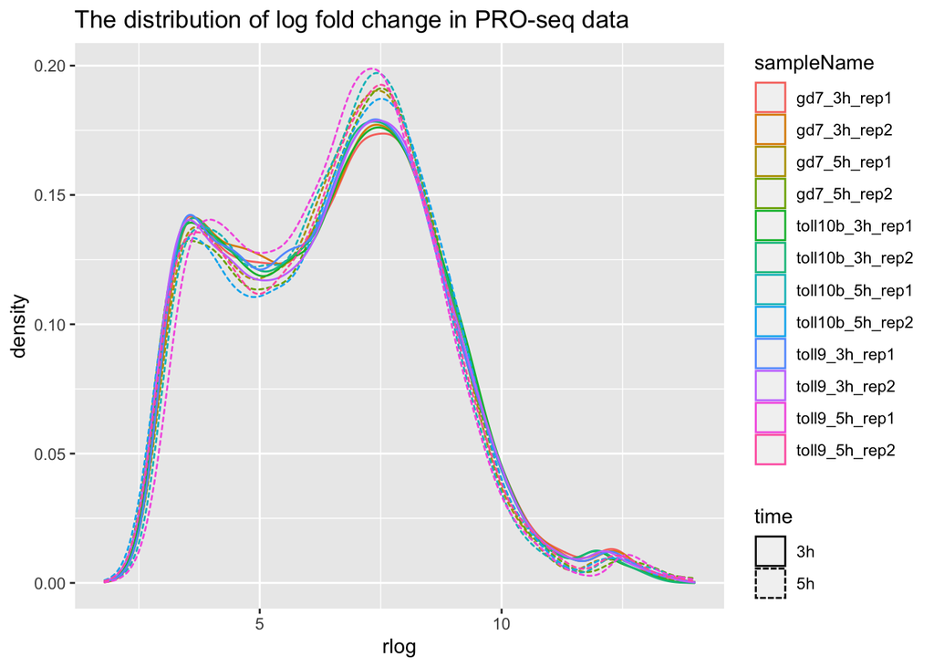

```r
# Merging the information of the log fold changes and the meta data
normExpression = as.data.frame(assay(rld))
normExpression$geneID = rownames(normExpression)
normExpressionDF  = normExpression %>% gather(key = sampleName, value = rlog,-geneID)
normExpressionDF = inner_join(normExpressionDF, sampleInfo.QC, by = "sampleName")

# Plotting the density(how many genes) of the rlog values.
ggplot(normExpressionDF,
       aes(
         x = rlog,
         color = sampleName,
         linetype = time
       )) + geom_density() + ggtitle("The distribution of log fold change in PRO-seq data")
```

### Density filtering

```r
# Summarizes statistical information in geneInfo per gene.
geneInfo.QC2 = normExpressionDF %>% dplyr::select(geneID, rlog, sampleName) %>%
  dplyr::group_by (geneID) %>%
  dplyr::summarize (
    min = min(rlog),
    max = max(rlog),
    mean = mean(rlog),
    sd = sd(rlog),
    #Creates a column which tells you how many counts(reads) are above 5 per gene.
    overQC = length(which(rlog > 5))
  )
```

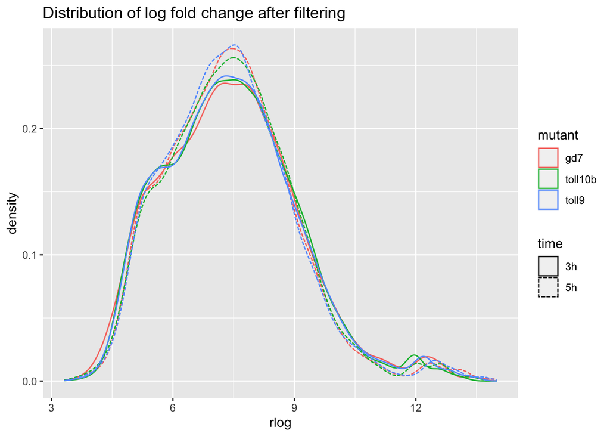

```r
# Requires the gene has at least 2 counts that have a log fold change over 5
geneInfo.QC3 = geneInfo.QC2 %>% filter(overQC > 2)
normExpressionDF.QC = normExpressionDF %>% filter(geneID %in% geneInfo.QC3$geneID)

# Plot the density of the log fold change
ggplot(normExpressionDF.QC, aes(
  x = rlog,
  color = mutant,
  linetype = time
)) + geom_density() + ggtitle("Distribution of log fold change after filtering")
```

```r
# We are only interested in the log values since we want to normalize them
normExpression.QC = normExpressionDF.QC %>%
  dplyr::select(geneID, sampleName, rlog) %>%
  spread(key = sampleName, value = rlog)

#Replace the column with geneIDs since the PCA only can handle numeric values
rownames(normExpression.QC) = normExpression.QC$geneID
normExpression.QC = normExpression.QC[,-1]
```

### Visualising the data

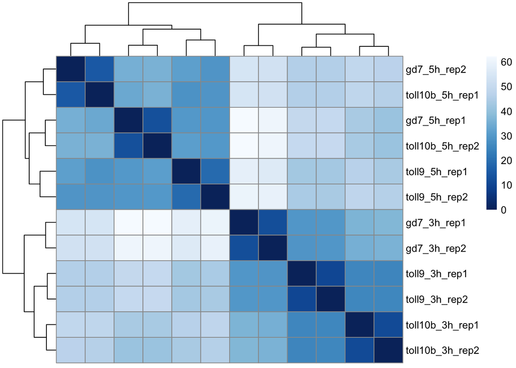

```r
# This is a function defined in ExpressionAnalysisFunctions.r
plotSample2SampleDistance(normExpression.QC)
```

```r
#'  __Figure 1 Plotting sample to sample distance__ .
#' Can see that the samples can be group by both mutant and time  .
```

### Principal components analysis with normalised counts

```r
# A principal component analysis on the merged information from the DESeq2 analysis, i.i the log fold change
mir.pca <-
  prcomp(t(normExpression.QC), center = TRUE, scale = FALSE)

# Calculates the variance
e.var = (mir.pca[['sdev']] ^ 2 / sum(mir.pca[['sdev']] ^ 2))
e.var = as.data.frame(e.var)
e.var$PC = as.factor(1:nrow(e.var))
e.var$Variance = e.var$e.var * 100
e.var$CumulativeVariance = cumsum(e.var$Variance)

# Creates a data frame with the loading scores
pctable = as.data.frame(mir.pca$x)[, 1:6]
# Join with the meta info to know which genes have which values
pctable$sampleName = rownames(pctable)
pctable = inner_join(pctable, metaInfo, by="sampleName")

# Plot a summary of the PCA that shows PC1-5 and the varibles(time and mutants)
pca  = plotPCAplot(
  PCAinfo = pctable,
  n.comp = 5,
  varianceInfo = e.var,
  colorComponent = "mutant",
  pchComponent = "time"
)
```

```
##          PC1         PC2       PC3       PC4        PC5  mutant time
## 1  -32.61633  -9.7648728 -7.102359 -6.942408 -0.7422872     gd7   3h
## 2  -30.88382  -9.0938192 -7.596212 -7.978458  2.3315877     gd7   3h
## 3   24.40983  12.5197602 -7.923948 -5.162697 -1.6984993 toll10b   5h
## 4   17.61737 -17.5823709 -6.734097  8.462770 -3.8649949     gd7   5h
## 5  -15.05461  16.4620043 -1.917485  7.706655  3.3038378 toll10b   3h
## 6  -12.53543  16.2354169 -1.745630  6.941265  4.3438282 toll10b   3h
## 7   18.13230 -16.4015587 -5.875838  7.901262  3.7906411     gd7   5h
## 8   24.01232  13.9013865 -8.444096 -5.544076 -4.7350740 toll10b   5h
## 9  -18.05471   0.6840110 11.460767  2.257527 -4.3366455   toll9   3h
## 10 -18.07562   0.4500838 11.655719  2.544647 -5.3353360   toll9   3h
## 11  20.22685  -3.5993013 11.888339 -6.245735 10.2819258   toll9   5h
## 12  22.82184  -3.8107399 12.334840 -3.940752 -3.3389837   toll9   5h
##    colorComponent pchComponent time_mutant
## 1             gd7           3h      3h_gd7
## 2             gd7           3h      3h_gd7
## 3         toll10b           5h  5h_toll10b
## 4             gd7           5h      5h_gd7
## 5         toll10b           3h  3h_toll10b
## 6         toll10b           3h  3h_toll10b
## 7             gd7           5h      5h_gd7
## 8         toll10b           5h  5h_toll10b
## 9           toll9           3h    3h_toll9
## 10          toll9           3h    3h_toll9
## 11          toll9           5h    5h_toll9
## 12          toll9           5h    5h_toll9
```

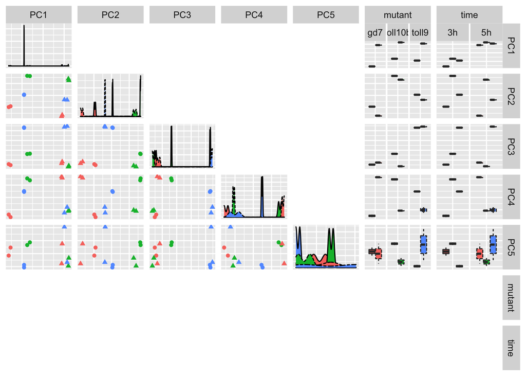

```r
# Actually run the command so it outputs the plot
pca
```

```r
# Calculate the mean of the PC to plot lines with respect to mutants
mean = pctable %>% dplyr::select(PC1, PC2, PC3, mutant) %>%
  dplyr::group_by(mutant) %>%
  dplyr::summarise(PC1 = mean(PC1) ,
                   PC2 = mean(PC2),
                   PC3 = mean(PC3))
# Do the same but with respect to time
meantime = pctable %>% dplyr::select(PC1, PC2, PC3, time) %>%
  dplyr::group_by(time) %>%
  dplyr::summarise(PC1 = mean(PC1) ,
                   PC2 = mean(PC2),
                   PC3 = mean(PC3))
# Create a vector plot with the values (-mean, origo, mean) for each variable, mutants and time
origo = data.frame(PC1 = 0, PC2 = 0, PC3 = 0)
line.gd7 = rbind(mean[1, 2:4], origo,-mean[1, 2:4])
line.gd7$factor = "Gd7"
line.toll10b = rbind(mean[2, 2:4], origo,-mean[2, 2:4])
line.toll10b$factor = "Toll10b"
line.toll9 = rbind(mean[3, 2:4], origo,-mean[3, 2:4])
line.toll9$factor = "Toll9"
line.time = rbind(meantime[2, 2:4], origo, meantime[1, 2:4])
line.time$factor = "Time"

# Does not include time here since we only want to plot the mutants
line = rbind(line.gd7, line.toll10b, line.toll9)

# Create a column in the pctable for the mutants and rename them to the previously used names
pctable$factor  = pctable$mutant
pctable$factor =  recode(pctable$factor, gd7 = "Gd7")
pctable$factor =  recode(pctable$factor, toll9 = "Toll9")
pctable$factor =  recode(pctable$factor, toll10b = "Toll10b")
```

### Plotting

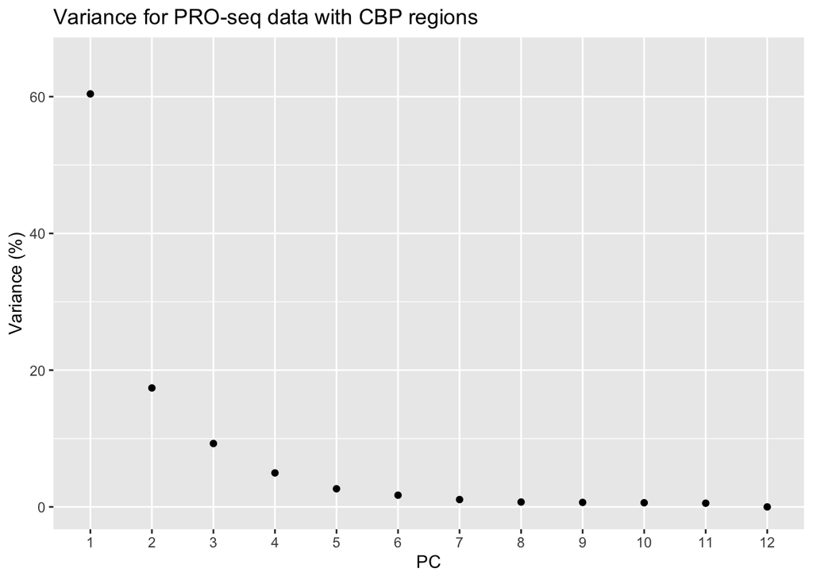

```r
# We want to see how much variance each principal component contains
qplot(
  PC,
  Variance,
  data = e.var,
  geom = c("point"),
  ylim = c(0, max(e.var$Variance) + 5),
  ylab = "Variance (%)",
  main = "Variance for PRO-seq data with CBP regions"
)
```

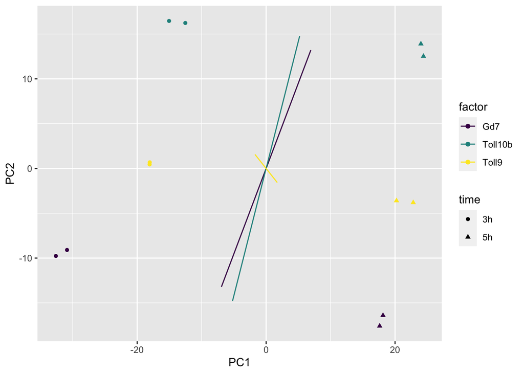

```r
#'  __Figure 2 Plotting PCA variance__.
#'  Displays how much each of the PC contributes to the overall expression.
#'  This suggest that the two first PC explains most of the variation.

#Plot how the mutants and time relates to the first 3 PCs
ggplot(line, mapping = aes(x = PC1, y = PC2, color = factor)) + geom_line() + geom_point(data = pctable,
                                                                                         mapping = aes(
                                                                                           x = PC1,
                                                                                           y = PC2,
                                                                                           color = factor,
                                                                                           shape = time
                                                                                         )) + scale_color_viridis(discrete = TRUE, option = "D")
```

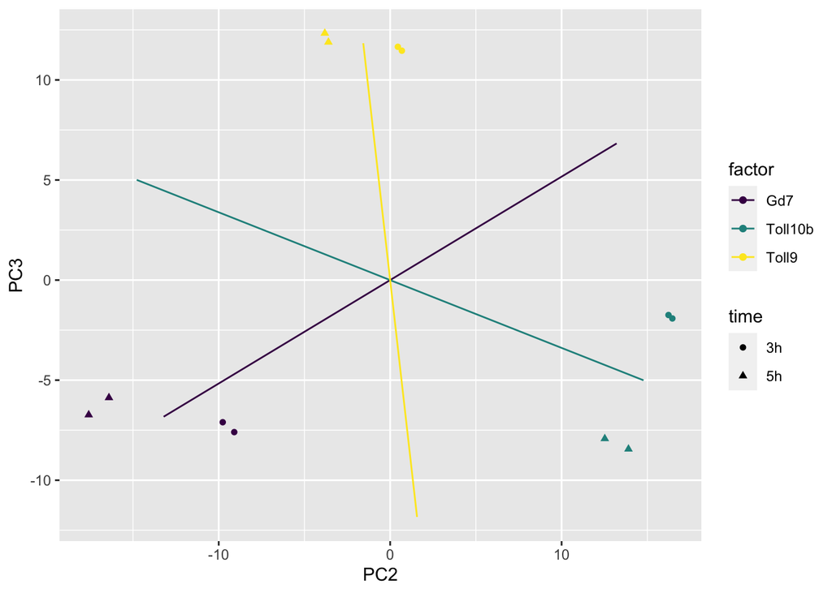

```r
ggplot(line, mapping = aes(x = PC2, y = PC3, color = factor)) + geom_line() + geom_point(data = pctable,
                                                                                         mapping = aes(
                                                                                           x = PC2,
                                                                                           y = PC3,
                                                                                           color = factor,
                                                                                           shape = time
                                                                                         )) + scale_color_viridis(discrete = TRUE, option = "D")
```

### Gene scores

The sequencing data has a lot of dimension, time and the different mutants. We want to reduce the number of dimensions to a single score. This is done by the loading scores found by PCA. The loading scores are used as a distance. The distance will then tell us how much variance is found, i.e. the bigger the distance the more it is different. We can e.g. from the scores say if a sample is up-regulated with respect to time

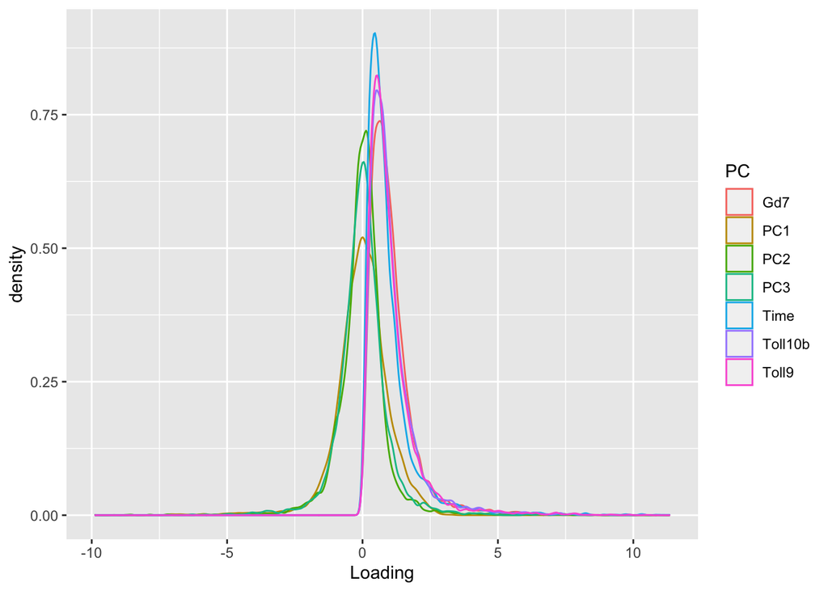

```r
# Saves the loading scores for PC1-PC3 for the mutants and time
line = rbind(line.gd7, line.toll10b, line.toll9, line.time)
loadings = mir.pca$rotation[, 1:3]

# Converts the loading values into z-values. A positive z-value ==> above average, negative ==> below average, 0 ==> average.
loadings_norm = as.data.frame(t((t(loadings) - colMeans(loadings)) / colSds(loadings)))
loadings_norm$geneID = rownames(loadings)

# We calculate the distance of each sample and mutant in the 3D space of PC1-3. The mean is seen as the "normal" expression and the distance is a measure of how large of a differential expression.
loadings_new = loadings_norm
for (j in unique(line$factor)) {
  loadings_new[[j]] = 0
  for (i in 1:nrow(loadings_norm)) {
    line1 = line %>% dplyr::filter(factor == j) %>% dplyr::select(PC1, PC2, PC3)
    loadings_new[i, j] = dist3d(
      b = as.numeric(line1[1,]),
      c = as.numeric(line1[3,]),
      point = as.numeric(loadings_norm[i, 1:3])
    )
  }
}

# Gather all of the new distances in a data frame for plotting
loadingsDF = gather(loadings_new, key = PC, value = Loading, -geneID)
ggplot(loadingsDF, mapping = aes(x = Loading, color = PC)) + geom_density()
```

```r
# Recreates the same data from as loadings_new but in another column order
loadingsDF.all = loadingsDF %>%  spread(key = PC, value = Loading)
tmp = loadingsDF.all

# Take the absolute value of the distance of the PC, to be able to compare them to each other and add it as a column to a new data frame
tmp$distance =  ((tmp$PC1 ^ 2 + tmp$PC2 ^ 2 + tmp$PC3 ^ 2) ^ 0.5)
loadingsDF.all = tmp
loadingsDF.all.factorDistance = loadingsDF.all %>% gather(key = factor, value = distance2Factor, Time, Gd7, Toll10b, Toll9)

# Calculates the distance by taking the distance for the loading scores to the distance to the factor(mutants or time). The bigger difference the more it is deviating form the norm. This means there will be one distance for each CBP Peak. (e.g. region 100 will have 4 column (time and mutants))
loadingsDF.all.factorDistance$distanceFactor = sqrt(
  loadingsDF.all.factorDistance$distance ^ 2 -
    loadingsDF.all.factorDistance$distance2Factor ^ 2
)

# To be able to calculate correctly the NA values are converted to 0 instead
loadingsDF.all.factorDistance$distanceFactor[is.na(loadingsDF.all.factorDistance$distanceFactor)] = 0

# Set the default value to down regulated
loadingsDF.all.factorDistance$direction = "Down"
# The mean is seen as up regulated, and down regulated as the negative value of the mean
line$Dir = rep(c("Up", "origo", "Down"), 4)

# Now we loop through all values and evaluate if it is up or down regulated with respect for each variable (time and mutants)
for (i in 1:nrow(loadingsDF.all.factorDistance)) {
  factor2 = loadingsDF.all.factorDistance[i,]$factor
  UpPoint = line %>% dplyr::filter(factor == factor2 &
                                     Dir == "Up") %>% dplyr::select(PC1, PC2, PC3)
  DownPoint = line %>% dplyr::filter(factor == factor2 &
                                       Dir == "Down") %>% dplyr::select(PC1, PC2, PC3)
  point = loadingsDF.all.factorDistance[i, c("PC1", "PC2", "PC3")]
  up = distance3d(as.numeric(UpPoint), as.numeric(point))
  down = distance3d(as.numeric(DownPoint), as.numeric(point))

  if (up < down) {
    loadingsDF.all.factorDistance[i, "direction"] = "Up"
  } else{
    loadingsDF.all.factorDistance[i, "distanceFactor"] =
      -loadingsDF.all.factorDistance[i, "distanceFactor"]
  }
}

# Collect all of the distances to the factors and have them in one column. Now there will be one distance per region
loadingsDF.all.factorDistance2 = loadingsDF.all.factorDistance %>% dplyr::select(geneID, PC1, PC2, PC3, distance, factor, distanceFactor) %>% spread(key = factor, value = distanceFactor)

# The max value is the biggest value of the distanceFactor for each geneID
loadingsDF.all.factorDistance.max = loadingsDF.all.factorDistance %>% group_by(geneID)
loadingsDF.all.factorDistance.max = loadingsDF.all.factorDistance.max %>% summarise(max = max(abs(distanceFactor)))
loadingsDF.all.factorDistance$max = abs(loadingsDF.all.factorDistance$distanceFactor)

# Add the max column to the rest of the data frame
loadingsDF.all.factorDistance.max = inner_join(loadingsDF.all.factorDistance,
                                               loadingsDF.all.factorDistance.max, by=c("geneID", "max")) %>% dplyr::select(geneID, factor, direction)

# Add the sample info
loadingsDF.all.factorDistance.max.peakInfo = inner_join (normExpressionDF.QC, loadingsDF.all.factorDistance.max)
# Add the loading scores
loadingsDF.all.factorDistance.max.peakInfo = inner_join(loadingsDF.all.factorDistance.max.peakInfo,
                                                        loadingsDF.all.factorDistance2,
                                                        by = "geneID")
```

### Print PROseq data to file

Saving the sampleInfo, geneInfo, Countdata and logarithmized countdata into files

```r
# Save the converted countdata as well as the sampleInfo
sampleInfoFile = paste(params$workingDir,
                       params$resultsDir,
                       "sampleInfo.QC.tab.txt",
                       sep = "/")
write.table(
  x = sampleInfo.QC,
  file = sampleInfoFile,
  quote = F,
  sep =  "\t",
  row.names = F,
  col.names = T
)
geneTableFile = paste(params$workingDir, params$resultsDir, "gene.QC.tab.txt", sep = "/")
write.table(
  x = geneInfo.QC,
  file = geneTableFile,
  quote = F,
  sep =  "\t",
  row.names = F,
  col.names = T
)
countTableFile = paste(params$workingDir,
                       params$resultsDir,
                       "counts.QC.tab.txt",
                       sep = "/")
write.table(
  x = countData.QC,
  file = countTableFile,
  quote = F,
  sep =  "\t",
  row.names = T,
  col.names = T
)
rlogTableFile = paste(params$workingDir, params$resultsDir, "rlog.QC.tab.txt", sep = "/")
write.table(
  x = normExpression.QC,
  file = rlogTableFile,
  quote = F,
  sep =  "\t",
  row.names = T,
  col.names = T
)

# Remove the PC values and save it in a tsv file
loadingsDF.all.factorDistance.max.peakInfo2 =
  loadingsDF.all.factorDistance.max.peakInfo %>%
  dplyr::select(-PC1,-PC2, -PC3, -distance)

output = inner_join(geneInfo.QC, loadingsDF.all.factorDistance.max.peakInfo2, by="geneID")

fileNamePROseq = paste(params$workingDir,
                       params$resultsDir,
                       params$PROseq.data,
                       sep = "/")
write.table(
  x = output,
  file = fileNamePROseq,
  quote = F,
  sep = "\t",
  col.names = T,
  row.names = F
)
```